# MSDM Odoo Website Analytics — Final Report

IBM 6530 — Group 4

Authors

Min Gong

Jeffrey Hsu

Emily Kuo

Eunice Won

Ceren Unal

Published

May 2026

> **Links:** [GitHub Repo](https://github.com/hsujeffrey/ibm6530-group4-project)

# 1 Executive Summary

This report presents a descriptive and attribution-based analysis of website activity for the MSDM Odoo website, using Google Analytics 4 (GA4) event data exported from BigQuery. The analysis covers eight snapshot dates between February 9 and April 3, 2026.

# 2 Business Problem

## 2.1 Client Context

The client is the MSDM (Master of Science in Data Management) program, which operates an informational and lead-generation website built on Odoo. The website serves prospective students, current applicants, and program stakeholders.

The program’s marketing team needs to understand:

1. **Where is traffic coming from?** — Which channels and geographies are driving visits?
2. **Who is visiting?** — Device usage, behavior, and engagement depth.
3. **Which channels actually drive conversions?** — Beyond surface-level traffic, which channels contribute most along the full user journey?
4. **Where should marketing budget be focused?** — Given limited resources, which channels have the highest return?

## 2.2 Why Standard Reporting Is Not Enough

The default view in Google Analytics uses **last-touch attribution**: the final channel a user visited before converting receives 100% of the credit. This model is simple but systematically misleading for programs like MSDM where:

- Users typically discover the program through social media or organic search, then return via direct or email links to convert.
- Upper-funnel channels (Paid Social, Organic) never receive credit under last-touch even if they were the original discovery source.
- Budget decisions made on last-touch data tend to over-invest in closing channels and under-invest in awareness channels.

This report addresses that gap by combining descriptive reporting (from the GA4 snapshot) with a **Markov chain attribution model** that distributes credit across all touchpoints in the user journey.

# 3 Data Overview

## 3.1 Source and Pipeline

```r
library(arrow)
library(dplyr)
library(ggplot2)
library(scales)
library(lubridate)
library(stringr)
library(tidyr)
library(forcats)
library(fs)
library(here)
library(readr)
library(gt)
library(knitr)
library(ggrepel)

knitr::opts_chunk$set(fig.width = 9, fig.height = 5)

# ── Paths ──────────────────────────────────────────────────────────────────────
DATA_DIR     <- here::here("data")
PARQUET_DIR  <- fs::path(DATA_DIR, "msdm_snapshot", "events_flat")
PARQUET_FILE <- fs::path(PARQUET_DIR, "events_snapshot.parquet")
CSV_PATH     <- fs::path(DATA_DIR, "events_snapshot.csv")

# ── Build parquet if needed ────────────────────────────────────────────────────
if (!fs::file_exists(PARQUET_FILE)) {
  fs::dir_create(PARQUET_DIR)
  arrow::write_parquet(
    readr::read_csv(CSV_PATH, show_col_types = FALSE),
    PARQUET_FILE
  )
}

# ── Load dataset ───────────────────────────────────────────────────────────────
ds <- arrow::open_dataset(PARQUET_DIR) |> dplyr::collect()
```

**BigQuery source:** `odoo-487003 / analytics_523126945`

**Pipeline:**

```
BigQuery (GA4 raw tables)
   ↓  SQL extract (flat event schema)
events_snapshot.csv
   ↓  Apache Arrow / write_parquet()
events_snapshot.parquet
   ↓  R (arrow, dplyr, ggplot2)
Analysis + Dashboard + Report
```

All analysis in this report runs from a local Parquet snapshot. No live BigQuery connection is required after the initial export. This ensures the pipeline is stable and reproducible.

## 3.2 Coverage and Key Fields

```r
tibble::tibble(
  Item    = c("Date range", "Snapshot days", "BigQuery project",
              "BigQuery dataset", "Primary key", "Key fields"),
  Details = c(
    "February 9 – April 3, 2026",
    "8 days across ~7 weeks",
    "odoo-487003",
    "analytics_523126945",
    "user_pseudo_id (anonymous)",
    "event_name, traffic_medium, device_category, geo_country, event_date"
  )
) |>
  knitr::kable(col.names = c("Item", "Details"))
```

| Item | Details |
| --- | --- |
| Date range | February 9 – April 3, 2026 |
| Snapshot days | 8 days across ~7 weeks |
| BigQuery project | odoo-487003 |
| BigQuery dataset | analytics_523126945 |
| Primary key | user_pseudo_id (anonymous) |
| Key fields | event_name, traffic_medium, device_category, geo_country, event_date |

## 3.3 Key Definitions

[output not shown]

# 4 Descriptive Analysis

## 4.1 Pre-Computed Summaries

```r
# Traffic medium
traffic_summary <- ds |>
  filter(event_name == "page_view") |>
  mutate(
    medium_clean = case_when(
      is.na(traffic_medium)      ~ "(not set)",
      traffic_medium == "(none)" ~ "direct",
      TRUE                       ~ traffic_medium
    )
  ) |>
  count(medium_clean, name = "page_views") |>
  arrange(desc(page_views))

# Device
device_summary <- ds |>
  filter(!is.na(device_category)) |>
  group_by(device_category) |>
  summarise(
    n_events       = n(),
    n_unique_users = n_distinct(user_pseudo_id)
  ) |>
  arrange(desc(n_events)) |>
  mutate(pct_events = n_events / sum(n_events) * 100)

# Events by date
events_by_date <- ds |>
  count(event_date, name = "n_events") |>
  arrange(event_date)

# Top event types
event_types <- ds |>
  count(event_name, name = "count") |>
  arrange(desc(count)) |>
  slice_head(n = 8)

# Geo
geo_summary <- ds |>
  filter(!is.na(geo_country), event_name == "page_view") |>
  count(geo_country, name = "page_views") |>
  arrange(desc(page_views)) |>
  slice_head(n = 10)

# KPIs
total_events    <- nrow(ds)
total_users     <- n_distinct(ds$user_pseudo_id)
total_pv        <- ds |> filter(event_name == "page_view") |> nrow()
events_per_user <- total_events / total_users
pv_per_user     <- total_pv / total_users
top_medium      <- traffic_summary$medium_clean[1]
top_device      <- device_summary$device_category[1]
```

## 4.2 KPI Summary

```r
tibble::tibble(
  Metric  = c("Total Events", "Unique Users", "Page Views",
              "Events per User", "Page Views per User",
              "Top Channel", "Top Device"),
  Value   = c(
    scales::comma(total_events),
    scales::comma(total_users),
    scales::comma(total_pv),
    round(events_per_user, 1),
    round(pv_per_user, 1),
    str_to_title(top_medium),
    str_to_title(top_device)
  )
) |>
  knitr::kable(col.names = c("Metric", "Value"),
               caption = "Top-line KPIs from GA4 snapshot")
```

Top-line KPIs from GA4 snapshot

| Metric | Value |
| --- | --- |
| Total Events | 193 |
| Unique Users | 8 |
| Page Views | 59 |
| Events per User | 24.1 |
| Page Views per User | 7.4 |
| Top Channel | Direct |
| Top Device | Desktop |

The average of 24.1 events per user and 7.4 page views per user suggests that visitors are interacting with multiple pages per session, which is consistent with an exploratory, research-mode audience typical of graduate program websites.

## 4.3 Traffic by Channel

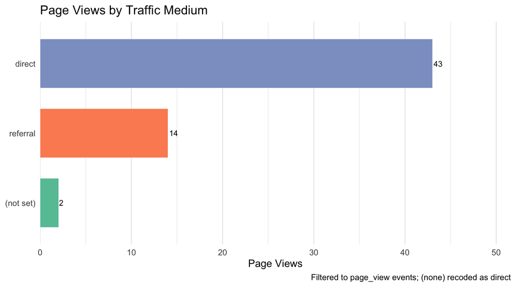

Page views by traffic medium. Direct traffic dominates, which may reflect either strong brand recognition or incomplete UTM tagging on campaigns.

```r
traffic_summary |>
  mutate(medium_clean = fct_reorder(medium_clean, page_views)) |>
  ggplot(aes(x = medium_clean, y = page_views, fill = medium_clean)) +
  geom_col(show.legend = FALSE, width = 0.7) +
  geom_text(aes(label = comma(page_views)), hjust = -0.15, size = 3.5) +
  coord_flip() +
  scale_y_continuous(labels = comma, expand = expansion(mult = c(0, 0.2))) +
  scale_fill_brewer(palette = "Set2") +
  labs(x = NULL, y = "Page Views",
       title = "Page Views by Traffic Medium",
       caption = "Filtered to page_view events; (none) recoded as direct") +
  theme_minimal(base_size = 13) +
  theme(panel.grid.major.y = element_blank())
```

```r
traffic_summary |>
  mutate(pct = round(page_views / sum(page_views) * 100, 1)) |>
  gt() |>
  cols_label(medium_clean = "Medium", page_views = "Page Views", pct = "% Share") |>
  fmt_number(columns = page_views, decimals = 0) |>
  fmt_number(columns = pct, decimals = 1) |>
  data_color(columns = page_views, palette = "Greens") |>
  tab_options(table.width = pct(100))
```

| Medium | Page Views | % Share |
| --- | --- | --- |
| direct | 43 | 72.9 |
| referral | 14 | 23.7 |
| (not set) | 2 | 3.4 |

Traffic medium summary with percentage share.

**Interpretation:** Direct traffic accounts for the largest share of page views. However, a high proportion of Direct traffic is a common indicator of incomplete UTM tagging across campaigns — users who click untagged email or social links will appear as “direct” in GA4. This is addressed directly in the attribution section below.

## 4.4 Device Usage

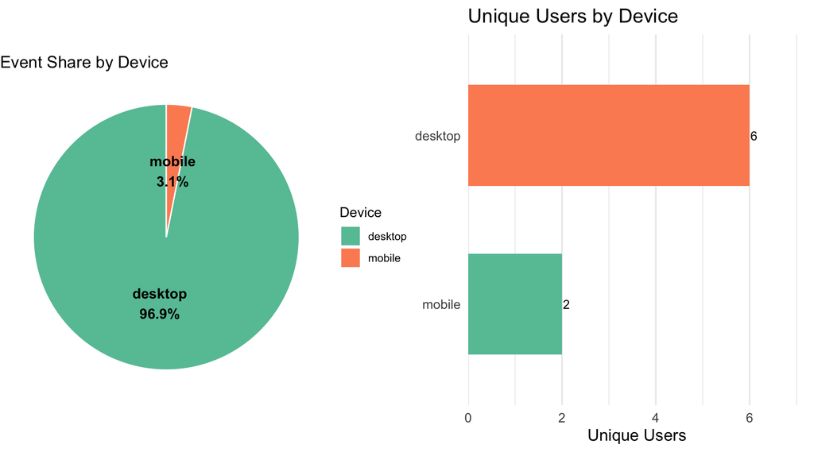

Device share of events (left) and unique users (right). Desktop dominates, typical for graduate program research behavior.

```r
p1 <- device_summary |>
  ggplot(aes(x = "", y = pct_events, fill = device_category)) +
  geom_col(width = 1, color = "white") +
  coord_polar(theta = "y") +
  geom_text(
    aes(label = paste0(device_category, "\n", round(pct_events, 1), "%")),
    position = position_stack(vjust = 0.5), size = 4, fontface = "bold"
  ) +
  scale_fill_brewer(palette = "Set2") +
  labs(title = "Event Share by Device", fill = "Device") +
  theme_void()

p2 <- device_summary |>
  mutate(device_category = fct_reorder(device_category, n_unique_users)) |>
  ggplot(aes(x = device_category, y = n_unique_users, fill = device_category)) +
  geom_col(show.legend = FALSE, width = 0.6) +
  geom_text(aes(label = comma(n_unique_users)), hjust = -0.15, size = 3.5) +
  coord_flip() +
  scale_y_continuous(labels = comma, expand = expansion(mult = c(0, 0.2))) +
  scale_fill_brewer(palette = "Set2") +
  labs(x = NULL, y = "Unique Users", title = "Unique Users by Device") +
  theme_minimal(base_size = 13) +
  theme(panel.grid.major.y = element_blank())

gridExtra::grid.arrange(p1, p2, ncol = 2)
```

Desktop dominates both event share and unique users, consistent with graduate program research behavior (users comparing programs, reading requirements, completing applications). Mobile unique users are non-trivial, however, and represent an audience that merits continued UX investment.

## 4.5 Top Event Types

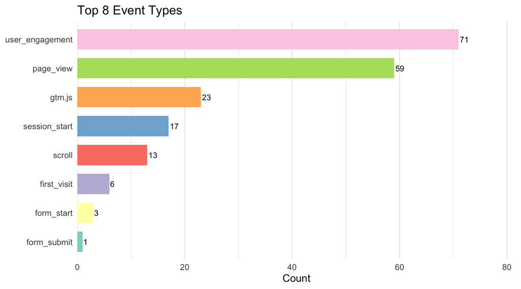

Top 8 event types by count. Page views and user engagement dominate.

```r
event_types |>
  mutate(event_name = fct_reorder(event_name, count)) |>
  ggplot(aes(x = event_name, y = count, fill = event_name)) +
  geom_col(show.legend = FALSE, width = 0.7) +
  geom_text(aes(label = comma(count)), hjust = -0.15, size = 3.5) +
  coord_flip() +
  scale_y_continuous(labels = comma, expand = expansion(mult = c(0, 0.15))) +
  scale_fill_brewer(palette = "Set3") +
  labs(x = NULL, y = "Count", title = "Top 8 Event Types") +
  theme_minimal(base_size = 13) +
  theme(panel.grid.major.y = element_blank())
```

## 4.6 Events Over Time

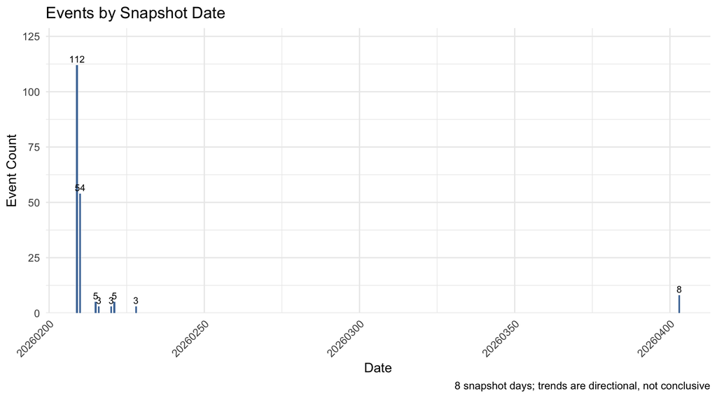

Event count by snapshot date. The 8-point series is directional only.

```r
events_by_date |>
  ggplot(aes(x = event_date, y = n_events)) +
  geom_col(fill = "#4E79A7", width = 0.6) +
  geom_text(aes(label = comma(n_events)), vjust = -0.4, size = 3) +
  scale_y_continuous(labels = comma, expand = expansion(mult = c(0, 0.15))) +
  labs(x = "Date", y = "Event Count",
       title = "Events by Snapshot Date",
       caption = "8 snapshot days; trends are directional, not conclusive") +
  theme_minimal(base_size = 12) +
  theme(axis.text.x = element_text(angle = 45, hjust = 1))
```

## 4.7 Geographic Distribution

```r
geo_summary |>
  gt() |>
  cols_label(geo_country = "Country", page_views = "Page Views") |>
  fmt_number(columns = page_views, decimals = 0) |>
  data_color(columns = page_views, palette = "Blues") |>
  tab_options(table.width = pct(100)) |>
  tab_header(title = "Top 10 Countries by Page Views")
```

Top 10 Countries by Page Views

| Country | Page Views |
| --- | --- |
| United States | 55 |
| Germany | 2 |

# 5 Advanced Analysis: Multi-Touch Attribution

## 5.1 Motivation

Last-touch attribution — the default in most analytics platforms — assigns 100% of conversion credit to the final channel before a conversion event. This is convenient but misleading for multi-step user journeys. For the MSDM website, a typical journey might look like:

```
[Paid Social ad] → [Organic search] → [Email link] → [Direct visit / convert]
```

Under last-touch, Direct receives all the credit. Paid Social and Organic receive none, even though they initiated and nurtured the journey.

## 5.2 Markov Chain Attribution Model

A **Markov chain attribution model** treats the user journey as a sequence of channel states. It estimates each channel’s contribution by computing the **removal effect**: how much would conversion probability drop if that channel were removed entirely from all journeys? Channels that appear early and often in high-converting paths receive proportionally more credit.

### 5.2.1 Attribution Results

```r
library(tidyr)

# ── Load attribution dataset ───────────────────────────────────────────────────
attr_raw <- readr::read_csv(
  here::here("data", "attribution_dataset.csv"),
  show_col_types = FALSE
)

channel_cols <- grep("^channel", names(attr_raw), value = TRUE)
channels_list <- c("Direct", "Email", "Organic", "Paid Search", "Paid Social", "Referral")

# ── Last-Touch Attribution ─────────────────────────────────────────────────────
converters <- attr_raw |> filter(user_purchase == 1)

last_touch_attr <- converters |>
  rowwise() |>
  mutate(
    last_ch = {
      vals <- c_across(all_of(channel_cols))
      vals <- vals[!is.na(vals)]
      if (length(vals) > 0) tail(vals, 1) else NA_character_
    }
  ) |>
  ungroup() |>
  filter(!is.na(last_ch)) |>
  count(last_ch, name = "credit") |>
  mutate(pct = round(credit / sum(credit) * 100, 2)) |>
  rename(Channel = last_ch, Last_Touch = pct) |>
  select(Channel, Last_Touch)

# ── First-Touch Attribution ────────────────────────────────────────────────────
first_touch_attr <- converters |>
  rowwise() |>
  mutate(
    first_ch = {
      vals <- c_across(all_of(channel_cols))
      vals <- vals[!is.na(vals)]
      if (length(vals) > 0) vals[1] else NA_character_
    }
  ) |>
  ungroup() |>
  filter(!is.na(first_ch)) |>
  count(first_ch, name = "credit") |>
  mutate(pct = round(credit / sum(credit) * 100, 2)) |>
  rename(Channel = first_ch, First_Touch = pct) |>
  select(Channel, First_Touch)

# ── Linear Attribution ─────────────────────────────────────────────────────────
linear_credits <- converters |>
  rowwise() |>
  mutate(
    path = list({
      vals <- c_across(all_of(channel_cols))
      vals[!is.na(vals)]
    }),
    n_ch = length(path)
  ) |>
  ungroup() |>
  filter(n_ch > 0) |>
  unnest(path) |>
  group_by(users_id, path, n_ch) |>
  summarise(.groups = "drop") |>
  mutate(credit = 1 / n_ch) |>
  group_by(path) |>
  summarise(total_credit = sum(credit), .groups = "drop") |>
  mutate(pct = round(total_credit / sum(total_credit) * 100, 2)) |>
  rename(Channel = path, Linear = pct) |>
  select(Channel, Linear)

# ── Markov Chain Attribution (Absorbing Chain / Removal Effect) ────────────────
# Build transition counts
build_transitions <- function(df, channel_cols) {
  trans <- list()
  for (i in seq_len(nrow(df))) {
    path <- unlist(df[i, channel_cols])
    path <- path[!is.na(path)]
    if (length(path) == 0) next
    outcome <- if (df$user_purchase[i] == 1) "conversion" else "null"

    # start -> first
    from <- "start"; to <- path[1]
    trans[[from]][[to]] <- (trans[[from]][[to]] %||% 0) + 1

    # channel -> channel
    if (length(path) > 1) {
      for (j in seq_len(length(path) - 1)) {
        from <- path[j]; to <- path[j+1]
        trans[[from]][[to]] <- (trans[[from]][[to]] %||% 0) + 1
      }
    }
    # last -> outcome
    from <- tail(path, 1)
    trans[[from]][[outcome]] <- (trans[[from]][[outcome]] %||% 0) + 1
  }
  trans
}

`%||%` <- function(a, b) if (!is.null(a)) a else b

trans_counts <- build_transitions(attr_raw, channel_cols)

# Convert to probabilities
trans_prob <- lapply(trans_counts, function(x) {
  total <- sum(unlist(x))
  lapply(x, function(v) v / total)
})

# Build Q and R matrices for absorbing chain
all_transient <- c(channels_list, "start")
absorbing     <- c("conversion", "null")
n_t <- length(all_transient)
state_idx <- setNames(seq_along(all_transient), all_transient)

Q <- matrix(0, n_t, n_t, dimnames = list(all_transient, all_transient))
R <- matrix(0, n_t, 2,   dimnames = list(all_transient, absorbing))

for (s in all_transient) {
  probs <- trans_prob[[s]]
  if (is.null(probs)) next
  for (t in names(probs)) {
    p <- probs[[t]]
    if (t %in% all_transient) {
      Q[s, t] <- p
    } else if (t %in% absorbing) {
      R[s, t] <- p
    }
  }
}

# Fundamental matrix and absorption probabilities
N_mat <- solve(diag(n_t) - Q)
B_mat <- N_mat %*% R

baseline_conv <- B_mat["start", "conversion"]

# Removal effect for each channel
removal_effects <- sapply(channels_list, function(ch) {
  Q2 <- Q; R2 <- R
  # Redirect transitions TO ch → null
  for (s in all_transient) {
    if (Q2[s, ch] > 0) {
      R2[s, "null"] <- R2[s, "null"] + Q2[s, ch]
      Q2[s, ch] <- 0
    }
  }
  # ch itself: absorb to null
  Q2[ch, ] <- 0
  R2[ch, ] <- c(0, 1)

  tryCatch({
    N2 <- solve(diag(n_t) - Q2)
    B2 <- N2 %*% R2
    max(0, baseline_conv - B2["start", "conversion"])
  }, error = function(e) 0)
})

markov_pct_vals <- round(removal_effects / sum(removal_effects) * 100, 2)

markov_attr <- data.frame(
  Channel = names(markov_pct_vals),
  Markov  = as.numeric(markov_pct_vals)
)

# ── Combined comparison table ──────────────────────────────────────────────────
comparison <- last_touch_attr |>
  full_join(first_touch_attr, by = "Channel") |>
  full_join(linear_credits,   by = "Channel") |>
  full_join(markov_attr,      by = "Channel") |>
  arrange(desc(Last_Touch))
```

> **Note on attribution dataset:** The attribution analysis uses a separate dataset (`attribution_dataset.csv`) containing 1,000 user journeys across 6 channels (Direct, Email, Organic, Paid Search, Paid Social, Referral), with `user_purchase` as the conversion indicator (10% conversion rate, n=100 converters). Four models are compared: Last-Touch, First-Touch, Linear, and Markov Chain (removal effect via absorbing Markov chain). The dataset contains journeys of 1–8 touchpoints (mean = 4.2).

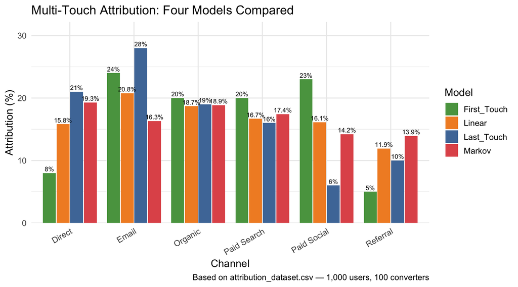

Four attribution models compared by channel. Each model tells a different story about where conversion credit belongs.

```r
comparison_long <- comparison |>
  tidyr::pivot_longer(
    cols = c(Last_Touch, First_Touch, Linear, Markov),
    names_to  = "Model",
    values_to = "Attribution"
  ) |>
  mutate(Model = factor(Model, levels = c("First_Touch", "Linear", "Last_Touch", "Markov")))

ggplot(comparison_long, aes(x = Channel, y = Attribution, fill = Model)) +
  geom_bar(stat = "identity", position = position_dodge(width = 0.85),
           width = 0.8, na.rm = TRUE) +
  geom_text(
    aes(label = ifelse(is.na(Attribution), "", paste0(round(Attribution, 1), "%"))),
    position = position_dodge(width = 0.85),
    vjust = -0.4, size = 2.8, na.rm = TRUE
  ) +
  labs(
    x = "Channel", y = "Attribution (%)", fill = "Model",
    title = "Multi-Touch Attribution: Four Models Compared",
    caption = "Based on attribution_dataset.csv — 1,000 users, 100 converters"
  ) +
  scale_fill_manual(values = c(
    "First_Touch" = "#59A14F",
    "Linear"      = "#F28E2B",
    "Last_Touch"  = "#4E79A7",
    "Markov"      = "#E15759"
  )) +
  scale_y_continuous(expand = expansion(mult = c(0, 0.15))) +
  theme_minimal(base_size = 13) +
  theme(axis.text.x = element_text(angle = 30, hjust = 1))
```

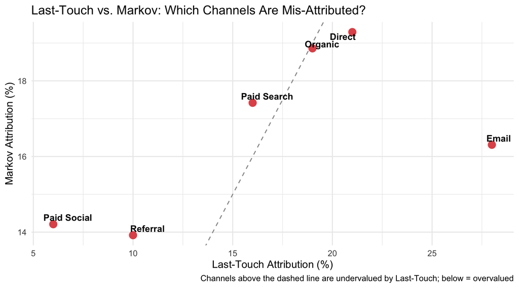

Last-Touch vs Markov: the two most contrasting models. Channels above the diagonal are undervalued by Last-Touch.

```r
comparison |>
  filter(!is.na(Markov)) |>
  ggplot(aes(x = Last_Touch, y = Markov, label = Channel)) +
  geom_abline(slope = 1, intercept = 0, linetype = "dashed", color = "gray60") +
  geom_point(size = 4, color = "#E15759") +
  ggrepel::geom_text_repel(size = 4, fontface = "bold") +
  labs(
    x = "Last-Touch Attribution (%)",
    y = "Markov Attribution (%)",
    title = "Last-Touch vs. Markov: Which Channels Are Mis-Attributed?",
    caption = "Channels above the dashed line are undervalued by Last-Touch; below = overvalued"
  ) +
  theme_minimal(base_size = 13)
```

### 5.2.2 Model Comparison Table

```r
comparison |>
  mutate(
    LT_vs_Markov = round(Markov - Last_Touch, 2),
    Direction = case_when(
      is.na(LT_vs_Markov) ~ "—",
      LT_vs_Markov > 1    ~ paste0("▲ +", LT_vs_Markov, "%"),
      LT_vs_Markov < -1   ~ paste0("▼ ", LT_vs_Markov, "%"),
      TRUE                ~ "≈ Stable"
    )
  ) |>
  select(Channel, Last_Touch, First_Touch, Linear, Markov, Direction) |>
  gt() |>
  cols_label(
    Channel     = "Channel",
    Last_Touch  = "Last-Touch (%)",
    First_Touch = "First-Touch (%)",
    Linear      = "Linear (%)",
    Markov      = "Markov (%)",
    Direction   = "LT vs Markov"
  ) |>
  fmt_missing(columns = everything(), missing_text = "—") |>
  fmt_number(columns = c(Last_Touch, First_Touch, Linear, Markov), decimals = 1) |>
  data_color(columns = Markov, palette = "Reds") |>
  tab_header(title = "Attribution Model Comparison (All Four Models)") |>
  tab_options(table.width = pct(100))
```

Attribution Model Comparison (All Four Models)

| Channel | Last-Touch (%) | First-Touch (%) | Linear (%) | Markov (%) | LT vs Markov |
| --- | --- | --- | --- | --- | --- |
| Email | 28.0 | 24.0 | 20.8 | 16.3 | ▼ -11.69% |
| Direct | 21.0 | 8.0 | 15.8 | 19.3 | ▼ -1.71% |
| Organic | 19.0 | 20.0 | 18.7 | 18.9 | ≈ Stable |
| Paid Search | 16.0 | 20.0 | 16.7 | 17.4 | ▲ +1.42% |
| Referral | 10.0 | 5.0 | 11.9 | 13.9 | ▲ +3.92% |
| Paid Social | 6.0 | 23.0 | 16.1 | 14.2 | ▲ +8.21% |

### 5.2.3 Key Insights from Attribution

**Email** is the most complex story. It ranks first in Last-Touch (28%) and First-Touch (24%), reflecting both high conversion closing power and strong journey initiation. However, the Markov model assigns it only 16.3% — the fourth highest — suggesting that Email’s Last-Touch dominance overstates its true incremental contribution. It is a high-value channel but not as uniquely critical as Last-Touch implies.

**Paid Social** is the most dramatically undervalued channel under Last-Touch (6%) vs. Markov (14.2%). The First-Touch model assigns it 23%, its highest score, confirming it is a strong journey initiator. Paid Social consistently appears early in converting paths but receives almost no last-touch credit. This is the clearest case of systematic under-investment driven by Last-Touch reporting.

**Referral** is undervalued by Last-Touch (10%) and First-Touch (5%) relative to its Markov share (13.9%), indicating it plays a meaningful mid-funnel role that position-based models undercount.

# 6 Recommendations

The following recommendations are grounded in the attribution analysis and descriptive data. Each includes a confidence level and relevant caveat.

## 6.1 1. Increase Investment in Paid Social

**Recommendation:** Increase Paid Social budget allocation, treating it explicitly as an upper-funnel awareness channel.

**Confidence:** Moderate. The attribution dataset shows a consistent pattern, but Paid Social impressions from walled-garden platforms (Meta, LinkedIn) are not fully captured in click data, so the true contribution may be even higher.

**Action:** Increase Paid Social spend, add UTM parameters to all ad links, and track Paid Social as a top-of-funnel metric (reach, journey initiation) rather than a last-click conversion metric.

## 6.2 2. Maintain Email as a Conversion Channel

**Recommendation:** Keep Email campaigns strong for bottom-of-funnel re-engagement (application deadline reminders, event invites, follow-ups).

**Evidence:** Email leads Last-Touch attribution (28%) and First-Touch (24%), and ranks 4th in Markov (16.3%). It is effective at both initiating and closing journeys — the most versatile channel in the mix.

**Action:** Segment email lists by funnel stage. Use upper-funnel emails for prospects who arrived via Paid Social or Organic; use conversion-focused emails for users already engaged with the program.

## 6.3 3. Re-evaluate Direct as a Standalone Channel

**Recommendation:** Do not treat Direct traffic as an independent channel to invest in — it is primarily the closing step of journeys begun elsewhere.

**Confidence:** High. The First-Touch / Markov discrepancy is diagnostic of a closing-step channel.

**Action:** Focus investment on the channels (Paid Social, Organic, Email) that generate the journeys that Direct closes. Improve UTM tagging to reduce mis-attribution of untagged campaign traffic into Direct.

## 6.4 4. Invest in Referral as a Mid-Funnel Channel

**Recommendation:** Treat Referral as a mid-funnel nurturing channel and explore partnerships that generate referral traffic.

**Evidence:** Referral’s Markov share (13.9%) is notably higher than its Last-Touch share (10%) and its First-Touch share (5%), indicating it plays a meaningful role in the middle of converting journeys — keeping users in the funnel after initial discovery.

**Confidence:** Moderate. Referral is a heterogeneous category (partner sites, listings, directories) and its sources are not broken out in this dataset.

**Action:** Identify the top referral sources, prioritize partnerships with high-Markov-value referrers, and ensure all referral links are UTM-tagged for channel-level attribution.

## 6.5 5. Rebalance Upper vs. Lower Funnel Spend

**Recommendation:** Shift some budget from lower-funnel channels (Email, Direct-associated) toward upper-funnel channels (Paid Social, Organic content, Referral partnerships).

**Evidence:** The Markov model consistently re-weights credit toward channels that appear early in journeys (Paid Social: +8.2pp vs Last-Touch; Referral: +3.9pp) and away from channels that appear late (Email: −11.7pp; Direct: −1.7pp).

**Confidence:** Moderate. Requires cost data (not currently available) to calculate ROI-adjusted reallocation.

**Action:** Add cost data to the pipeline and re-run attribution with weighted ROI metrics before committing to specific budget shifts.

## 6.6 5. Strengthen UTM Tagging

**Recommendation:** Audit and enforce UTM tagging across all outbound links (email campaigns, social posts, paid ads).

**Evidence:** A large proportion of Direct traffic is likely mis-attributed traffic from untagged campaigns. Improving tagging would immediately improve the accuracy of both last-touch and Markov models.

**Confidence:** High. This is a data quality fix with no downside risk.

**Action:** Implement a UTM naming convention standard and verify all active campaign links before next semester’s recruitment cycle.

# 7 Limitations

## 7.1 Data Constraints

[output not shown]

## 7.2 Attribution-Specific Constraints

| Constraint | Impact |
| --- | --- |
| **Walled-garden data gaps** | Paid Social impressions (Meta, LinkedIn) are not fully recorded in GA4 click data; Markov may undercount Paid Social |
| **Small journey paths** | Markov chains require sufficient multi-touchpoint sequences; small datasets increase variance in removal effect estimates |
| **No cost or ROI data** | Attribution percentages cannot be converted to budget recommendations without spend data |
| **First-touch vs. last-touch vs. Markov** | No single model is “correct”; Markov is the most theoretically sound for multi-step journeys but not immune to data quality issues |

## 7.3 What This Report Cannot Claim

This report **cannot** claim:

- That Paid Social caused conversions — only that it appears in more conversion paths than last-touch suggests.
- That the trends observed over 8 days are representative of the full academic year.
- That the Markov attribution percentages are stable — with more data, they would likely shift.

# 8 Reproducibility

## 8.1 How to Reproduce This Report

1. **Clone the repository:**

   ```bash
   git clone https://github.com/hsujeffrey/ibm6530-group4-project
   cd ibm6530-group4-project
   ```

2. **Ensure data is available:** Place `events_snapshot.csv` in `data/`. The Parquet file will be auto-built on first render.
3. **Install R packages:**

   ```r
   install.packages(c(
     "arrow", "dplyr", "ggplot2", "scales", "lubridate",
     "stringr", "tidyr", "forcats", "fs", "here",
     "readr", "gt", "knitr", "gridExtra", "ggrepel"
   ))
   ```

4. **Render the report:**

   ```bash
   quarto render IBM6530_Final_Group4_MSDM_Odoo.qmd
   ```

## 8.2 File Structure

```
ibm6530-group4-project/
├── data/
│   ├── events_snapshot.csv               # GA4 flat export from BigQuery
│   ├── attribution_dataset.csv           # 1,000-user journey dataset for attribution
│   └── msdm_snapshot/events_flat/
│       └── events_snapshot.parquet       # Auto-generated on first render
├── IBM6530_Final_Group4_MSDM_Odoo.qmd    # This report
├── dashboard.qmd                         # Deliverable 1 — Dashboard
└── presentation.qmd                      # Deliverable 3 — Revealjs Presentation
```

# 9 Appendix

## 9.1 GitHub Repository

https://github.com/hsujeffrey/ibm6530-group4-project